# Podstawy R i RStudio

Tomasz Olczyk

2025-06-09

## Założenia

### Reprodukowalność i literate programming

Wszystkie wyniki (tabele, wykresy itp) powinny byc procedualnie i reprodukowalnie generowane z zapisanego kodu, zapisane w prostym formacie opartym na tekście. Możliwość reprodukowania własnej pracy jest kluczowa w nauce, ale także ze względów czysto praktycznych. Osobą, która będzie najczęściej reprodukować Twoje wyniki jesteś Ty za sześć miesięcy.

Celem jest maksymalnie programatyczna analiza. Staramy się nie używać sposobów, które nie są programatycznie reprodukowalne.

Zadania:

1. pisanie kodu
2. analiza wyników
3. notatki

Dlatego używamy RMakdown. Jest to czysto tekstowy dokument, który umożliwia robienie tych wszystkich rzeczy, w sposób reprodukowalny i zapisany w możliwie odporny sposób.

### Projekt elementy podstawowe

Otwieranie nowego projektu:

File > New project

File > New File > Rmarkdown

znak `#` oznacza komentarz wewnętrz segmentu kodu.WRmarkdown odnosi się do poziomu nagłówka.

### Pozwalajmy sobie na błędy

R zawsze robi to co mu każemy zrobić, ale nie zawsze to, co chcemy żeby zrobił. Inaczej mówiąc R traktuje wszystkie polecenia literalnie.

Będziemy popełniać błędy i będzie ich mnóstwo. Błędy pomagają nauczyć się programowania w R.

Typowe błędy: - niedomknięty nawias, - niekompletne wyrażanie (+ w konsoli, kursor + Esc) - częsty błąd ggplot to + w niewłaściwm miejscu

#### skróty klawiszowe

Ctrl+Alt+ I - nowy segment kodu w Windowsie Cmd+Alt + I = nowy segment kodu w Mac os

## RStudio podstawwowe informacje

- Panele
- Pliki
- Skrypty
- RMarkdown
- Konsola

## Instalacja pakietów

Pakiet R jest kolekcją funkcji, danych i dokumentacji, która rozszerza możliwości bazowego R

Pliki R markdown składają się z nagłówka, segmentów tekstu i specjalnie oznaczonych segmentów kodu(code chunk). Skrypty składają się z kodu i komentarzy poprzedzonych #. W markdown “domyślną” treścią jest tekst “do czytania”, kod jest dodatkiem, dlatego znajduje się w specjalnie zaznaczonych segmentach. Raportom w R markdown poświęcimy więcej czasu w drugim segmencie szkolenia.

W skryptach jest na odwrót, dlatego tekst trzeba poprzedzać `#` żeby program nie uznał go za kod.

Biblioteki instalujmy funkcją install.packages() której argumentem jest nazwa biblioteki w cudzysłowie. Bibliotekę wystarczy zainstalować raz.

Poniższy segment jest nazywany code chunk:

```r
# kod w tym segmencie instaluje bibliotekę tidyverse

#install.packages("tidyverse")

# hash przed kodem sprawia, że znaki po nim są traktowane jak komentarz, kod nie będzie wykonany
```

## Wczytywanie pakietów (bibliotek)

Pakiety wczytujemy funkcją library(). Biblioteki dobrze jest wczytywać na początku analizy. Biblioteka powinna być wczytana przed użyciem funkcji w niej zawartej. Można użyć funkcji bez wczytywania używając składni: biblioteka::funkcja

```r
library(tidyverse)
#install.packages("gapminder")
library(gapminder)
```

# Obiekty i funkcje

W R wszystko jest obiektem.

Nazwy obiektów muszą rozpoczynać się od litery i mogą zawierać tylko litery, cyfry znak _ oraz . .

Wszystko ma nazwę:

zmienne, dane, funkcje.

Do nadawania nazw nie wolno używać m.in: FALSE, TRUE, Inf, for, else, break, function. Lepiej nie używać we własnych nazwach nazw funkcji, szczególnie z pakiety podstawowego jak c() - konkatentacja, q(), mean(), var(), range() i podobnych.

Wszystko jest obiektem:

```r
# przypisuje kolekcję liczb do nazwy  moje liczby
# operator przypisania <- można uzyskać skrótem Alt - na Windowsie, Opt - na mac

moje_liczby  <- c(1, 2, 3, 5, 25) # funkcja c() tworzy wektor czyli uporządkowaną kolekcję elementów jednego rodzaju
```

Operator przypisania skróty: -mac os: Opt + - -Win: Alt + -

Po przypisaniu i wykonaniu kodu obiekt pojawi się w przestrzeni roboczej: okno environment.

Operator przypisania łączy obiekt z nazwą.

Działania wykonuje się za pomocą funkcji:

Kiedy chcemy żeby funkcja wykonała jakieś działanie wywołujemy ją. Funkcje mają nawiasy na końcu swojej nazwy. Funkcje wykonują działania na podstawie wartości przyjmowanych przez ich argumenty

nazwa_funkcji(argument1 = , argument2 = , argument2 = )

Argumenty zawsze oddzielone są przecinkami

### Pomoc

```r
?help()
```

```r
help(ggplot)
```

### Przykładowe funkcje

```r
# funkcja licząca średnią
mean()
```

```
## Error in mean.default(): argument "x" is missing, with no default
```

Komunikat o błędzie: **Error in mean.default() : argument “x” is missing, with no default** W tym wypadku infomuje o tym, że wartosć argumentu x nie została podana Ogólnie jeśli wartość argumentu nie jest liczbą, obiektem istniejącym w przestrzeni roboczej albo wartością logiczną to jest podawana w cudzysłowie (por. instalowanie biblioteki versus wczytywanie biblioteki)

```r
# najczęście nie trzeba podawać nazw argumentów, wystarczy podanie ich wartości w odpowiedniej kolejności
mean(moje_liczby)
```

```
## [1] 7.2
```

Rezultaty działania funkcji można przypisać do obiektów

```r
podsumowanie <- summary(moje_liczby)
podsumowanie # wyświetla obiekt w konsoli
```

```
##    Min. 1st Qu.  Median    Mean 3rd Qu.    Max.
##     1.0     2.0     3.0     7.2     5.0    25.0
```

```r
# zwraca tabelę liczności elementów

table(moje_liczby)
```

```
## moje_liczby
##  1  2  3  5 25
##  1  1  1  1  1
```

```r
# zwraca odchylenie standardowe

sd(moje_liczby)
```

```
## [1] 10.05982
```

```r
# mnoży każdy element przez 5

moje_liczby * 5
```

```
## [1]   5  10  15  25 125
```

```r
# dodaje  5 do każdego elementu

moje_liczby + 5
```

```
## [1]  6  7  8 10 30
```

```r
# operacja wektoryzowana, kolejne elementy jednego wektora dodane do kolejnych elementów drugiego wyktora
moje_liczby + moje_liczby
```

```
## [1]  2  4  6 10 50
```

Każdy obiekt ma klasę, którą możemy spawdzic funkcją `class()`

```r
class(moje_liczby)
```

```
## [1] "numeric"
```

```r
podsumowanie <- summary(moje_liczby)
class(podsumowanie)
```

```
## [1] "summaryDefault" "table"
```

```r
class(summary)
```

```
## [1] "function"
```

Operacje wykonywane na obiektach mogą skutkować zmianą ich klasy:

```r
nowy_wektor <- c(moje_liczby, "jabłko")
class(nowy_wektor)
```

```
## [1] "character"
```

Zbiory danych zaimportowane do R też są obiektami. W R jest kilka typów obiektów służących do przechowywania danych ale najbadziej typowym jest ramka danych: data frame. Ramka danych to prostokątna tabela zlożona z wierszy (obserwacji) i kolumn (zmiennych). Kolumny w ramce danych mogą być różnej klasy.

### Liczby

```r
class(1)
```

```
## [1] "numeric"
```

### Znaki

```r
class("1")
```

```
## [1] "character"
```

### Logiczne

```r
two <- 2 # strzałka jest operatorem przypisania, przypisuje obiekt do nazwy

Two <- 2 #wielkie litery mają znaczenie
```

### Operatory

```r
logiczne <- two == Two # podwójny znak = oznacza w R równa się

logiczne
```

```
## [1] TRUE
```

```r
nierówna_się <- two != Two

nierówna_się
```

```
## [1] FALSE
```

Obiekt i operator przypisania. Zapisuje obiekt “data”, zawierający dane gapminder

```r
data <- (gapminder)
```

### Wgląd w dane w ramce

```r
str(data)
```

```
## tibble [1,704 × 6] (S3: tbl_df/tbl/data.frame)
##  $ country  : Factor w/ 142 levels "Afghanistan",..: 1 1 1 1 1 1 1 1 1 1 ...
##  $ continent: Factor w/ 5 levels "Africa","Americas",..: 3 3 3 3 3 3 3 3 3 3 ...
##  $ year     : int [1:1704] 1952 1957 1962 1967 1972 1977 1982 1987 1992 1997 ...
##  $ lifeExp  : num [1:1704] 28.8 30.3 32 34 36.1 ...
##  $ pop      : int [1:1704] 8425333 9240934 10267083 11537966 13079460 14880372 12881816 13867957 16317921 22227415 ...
##  $ gdpPercap: num [1:1704] 779 821 853 836 740 ...
```

Wyświetla 6 pierwszych wierszy

```r
head(data)
```

```
## # A tibble: 6 × 6
##   country     continent  year lifeExp      pop gdpPercap
##   <fct>       <fct>     <int>   <dbl>    <int>     <dbl>
## 1 Afghanistan Asia       1952    28.8  8425333      779.
## 2 Afghanistan Asia       1957    30.3  9240934      821.
## 3 Afghanistan Asia       1962    32.0 10267083      853.
## 4 Afghanistan Asia       1967    34.0 11537966      836.
## 5 Afghanistan Asia       1972    36.1 13079460      740.
## 6 Afghanistan Asia       1977    38.4 14880372      786.
```

Wyświetla ramkę danych w lewym panelu

```r
View(data)
```

Wyświetla ostatnich sześć wierszy

```r
tail(data)
```

```
## # A tibble: 6 × 6
##   country  continent  year lifeExp      pop gdpPercap
##   <fct>    <fct>     <int>   <dbl>    <int>     <dbl>
## 1 Zimbabwe Africa     1982    60.4  7636524      789.
## 2 Zimbabwe Africa     1987    62.4  9216418      706.
## 3 Zimbabwe Africa     1992    60.4 10704340      693.
## 4 Zimbabwe Africa     1997    46.8 11404948      792.
## 5 Zimbabwe Africa     2002    40.0 11926563      672.
## 6 Zimbabwe Africa     2007    43.5 12311143      470.
```

Funkcja glimpse z pakietu dplyr. Nazwa funkcji poprzedzona dwukropkiem i nazwą biblioteki informuje/ustala, z której biblioteki ma być zastosowana funkcja o danej nazwie. Przydatne, gdy jest wiele funkcji o tych samych nazwach z różnych bibliotek,

```r
dplyr::glimpse(data)
```

```
## Rows: 1,704
## Columns: 6
## $ country   <fct> "Afghanistan", "Afghanistan", "Afghanistan", "Afghanistan", …
## $ continent <fct> Asia, Asia, Asia, Asia, Asia, Asia, Asia, Asia, Asia, Asia, …
## $ year      <int> 1952, 1957, 1962, 1967, 1972, 1977, 1982, 1987, 1992, 1997, …
## $ lifeExp   <dbl> 28.801, 30.332, 31.997, 34.020, 36.088, 38.438, 39.854, 40.8…
## $ pop       <int> 8425333, 9240934, 10267083, 11537966, 13079460, 14880372, 12…
## $ gdpPercap <dbl> 779.4453, 820.8530, 853.1007, 836.1971, 739.9811, 786.1134, …
```

### Wektory

Tworzenie wektorów

```r
partie <- c("KO", "PiS", "Lewica", "Konfederacja", "TD")


partie
```

```
## [1] "KO"           "PiS"          "Lewica"       "Konfederacja" "TD"
```

Wektor napisów

```r
class(partie)
```

```
## [1] "character"
```

Wektor liczb

```r
sondaż <- c(29, 35, 10, 10, 10)
```

```r
typeof(sondaż)
```

```
## [1] "double"
```

```r
# w języku R klasa double reprezentuje liczby zmiennoprzecinkowe o podwójnej precyzji (double precision)
```

```r
class(sondaż)
```

```
## [1] "numeric"
```

Indeksowanie

```r
wektor <- 3:103
```

```r
wektor[0]
```

```
## integer(0)
```

```r
wektor[1]
```

```
## [1] 3
```

```r
LETTERS
```

```
##  [1] "A" "B" "C" "D" "E" "F" "G" "H" "I" "J" "K" "L" "M" "N" "O" "P" "Q" "R" "S"
## [20] "T" "U" "V" "W" "X" "Y" "Z"
```

```r
co_drugi <- seq(from = 1, to = length(LETTERS), by  = 2)

LETTERS[co_drugi]
```

```
##  [1] "A" "C" "E" "G" "I" "K" "M" "O" "Q" "S" "U" "W" "Y"
```

### Ramki danych

Matryca (macierz) z dwóch wektorów

```r
matryca <- cbind(partie, sondaż)
matryca
```

```
##      partie         sondaż
## [1,] "KO"           "29"
## [2,] "PiS"          "35"
## [3,] "Lewica"       "10"
## [4,] "Konfederacja" "10"
## [5,] "TD"           "10"
```

```r
glimpse(matryca)
```

```
##  chr [1:5, 1:2] "KO" "PiS" "Lewica" "Konfederacja" "TD" "29" "35" "10" "10" ...
##  - attr(*, "dimnames")=List of 2
##   ..$ : NULL
##   ..$ : chr [1:2] "partie" "sondaż"
```

Ramka danych (data frame) z dwóch wektorów:

```r
ramka_danych <- data.frame(partie, sondaż)
```

```r
glimpse(ramka_danych)
```

```
## Rows: 5
## Columns: 2
## $ partie <chr> "KO", "PiS", "Lewica", "Konfederacja", "TD"
## $ sondaż <dbl> 29, 35, 10, 10, 10
```

Jak połączyć wektory nierównych długości w ramkę danych: [link](https://www.geeksforgeeks.org/create-dataframe-of-unequal-length-in-r/)

```r
str(ramka_danych)
```

```
## 'data.frame':    5 obs. of  2 variables:
##  $ partie: chr  "KO" "PiS" "Lewica" "Konfederacja" ...
##  $ sondaż: num  29 35 10 10 10
```

Prosty wykres w bazowym R:

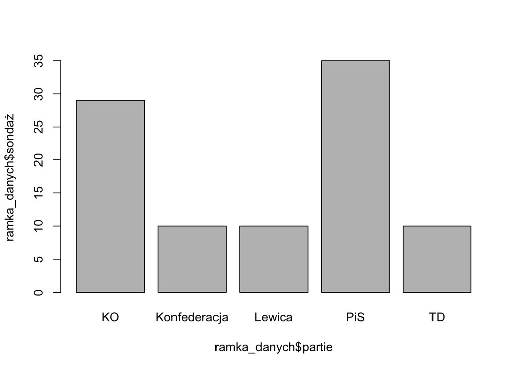

```r
barplot(ramka_danych$sondaż
        ~ ramka_danych$partie)
```

# Wczytywanie danych

Podstawowe funkcje do wczytywania danych:

```r
?read.delim
```

```r
?read.table
```

Funkcje mają zazwyczaj długą listę argumentów, z których większość ma domyślne wartości.

```r
read.table(file,
           header = FALSE,
           sep = "",
           quote = "\"'",
           dec = ".", numerals = c("allow.loss", "warn.loss", "no.loss"),
           row.names, col.names,
           as.is = !stringsAsFactors,
           na.strings = "NA",
           colClasses = NA,
           nrows = -1,
           skip = 0,
           check.names = TRUE,
           fill = !blank.lines.skip,
           strip.white = FALSE,
           blank.lines.skip = TRUE,
           comment.char = "#",
           allowEscapes = FALSE, flush = FALSE,
           stringsAsFactors = FALSE,
           fileEncoding = "",
           encoding = "unknown",
           text,
           skipNul = FALSE)
```

```r
?read.csv()
```

```r
read.csv(file, header = TRUE, sep = ",", quote = "\"",
         dec = ".", fill = TRUE, comment.char = "", ...)

read.csv2(file, header = TRUE, sep = ";", quote = "\"",
          dec = ",", fill = TRUE, comment.char = "", ...)

read.delim(file, header = TRUE, sep = "\t", quote = "\"",
           dec = ".", fill = TRUE, comment.char = "", ...)

read.delim2(file, header = TRUE, sep = "\t", quote = "\"",
            dec = ",", fill = TRUE, comment.char = "", ...)
```

```r
?readr::read_delim
```

```r
read_delim(
  file,
  delim = NULL,
  quote = "\"",
  escape_backslash = FALSE,
  escape_double = TRUE,
  col_names = TRUE,
  col_types = NULL,
  col_select = NULL,
  id = NULL,
  locale = default_locale(),
  na = c("", "NA"),
  quoted_na = TRUE,
  comment = "",
  trim_ws = FALSE,
  skip = 0,
  n_max = Inf,
  guess_max = min(1000, n_max),
  name_repair = "unique",
  num_threads = readr_threads(),
  progress = show_progress(),
  show_col_types = should_show_types(),
  skip_empty_rows = TRUE,
  lazy = should_read_lazy()
)

read_csv(
  file,
  col_names = TRUE,
  col_types = NULL,
  col_select = NULL,
  id = NULL,
  locale = default_locale(),
  na = c("", "NA"),
  quoted_na = TRUE,
  quote = "\"",
  comment = "",
  trim_ws = TRUE,
  skip = 0,
  n_max = Inf,
  guess_max = min(1000, n_max),
  name_repair = "unique",
  num_threads = readr_threads(),
  progress = show_progress(),
  show_col_types = should_show_types(),
  skip_empty_rows = TRUE,
  lazy = should_read_lazy()
)

read_csv2(
  file,
  col_names = TRUE,
  col_types = NULL,
  col_select = NULL,
  id = NULL,
  locale = default_locale(),
  na = c("", "NA"),
  quoted_na = TRUE,
  quote = "\"",
  comment = "",
  trim_ws = TRUE,
  skip = 0,
  n_max = Inf,
  guess_max = min(1000, n_max),
  progress = show_progress(),
  name_repair = "unique",
  num_threads = readr_threads(),
  show_col_types = should_show_types(),
  skip_empty_rows = TRUE,
  lazy = should_read_lazy()
)

read_tsv(
  file,
  col_names = TRUE,
  col_types = NULL,
  col_select = NULL,
  id = NULL,
  locale = default_locale(),
  na = c("", "NA"),
  quoted_na = TRUE,
  quote = "\"",
  comment = "",
  trim_ws = TRUE,
  skip = 0,
  n_max = Inf,
  guess_max = min(1000, n_max),
  progress = show_progress(),
  name_repair = "unique",
  num_threads = readr_threads(),
  show_col_types = should_show_types(),
  skip_empty_rows = TRUE,
  lazy = should_read_lazy()
)
```

```r
panteon <- read_csv(here::here("dane", "panteon_s.csv"))
panteon <- read_csv("https://raw.githubusercontent.com/Tomasz-Olczyk/wizualizacjaR/main/podstawy/panteon_s.csv")
```

### Inne niż csv typy plików wejściowych

Do R można wczytać (a także eksportować z R) dane w bardzo wielu różnych formatach, m.in dane wyjściowe: SPSS, STATA, SAS. W przypadku wymienionych (a także innych formatów) odpowiednie funcje zawierają np. biblioteki foreign [link](https://cran.r-project.org/web/packages/foreign/index.html) i haven link

Dane z arkuszy google można wczytywać funkcją biblioteki googlesheets4

Można również zczytywać tabele z danymi ze stron internetowych za pomocą biblioteki rvest (np. z wikipedii) czy z plików pdf za pomocą biblioteki tabulizer.

Praktycznie każde działanie w R można wykonać co najmniej na kilka sposobów za pomocą różnych funkcji różnych pakietów. Dotyczy to zarówno analizy, grafiki jak i wczytywania plików.

Do wczytywania plików excela można wykorzystać bibliotekę readxl

```r
#install.packages("readxl")
library(readxl)
```

Biblioteka ta ma kilka funkcji wczytujących pliki excelowskie np read_excel która sama ustala czy plik ma rozszerzenie xls czy xlsx ale także funkcje read_xls, i read_xlsx, których możemy użyć jeśli znamy rozszerzenie pliku

```r
read_excel(
  path,
  sheet = NULL,
  range = NULL,
  col_names = TRUE,
  col_types = NULL,
  na = "",
  trim_ws = TRUE,
  skip = 0,
  n_max = Inf,
  guess_max = min(1000, n_max),
  progress = readxl_progress(),
  .name_repair = "unique"
)
```

Problem ścieżek absolutnych i relatywnych

```r
podatki <- read_excel(
  "./dane/Chapter14TablesFigures.xlsx", #uwaga musimy być we właściwym katalogu roboczym, żeby ta linia kodu zadziałała
  sheet = "TS14.1", #wybieramy arkusz z pliku
  skip = 3 # usuwamy trzy pierwsze wiersze
  )
```

```
## Error: `path` does not exist: './dane/Chapter14TablesFigures.xlsx'
```

```r
str(podatki)
```

```
## Error in str(podatki): object 'podatki' not found
```

```r
dplyr::glimpse(podatki)
```

```
## Error in dplyr::glimpse(podatki): object 'podatki' not found
```

Dobrą ale nieco wolniejszą biblioteką jest openxlsx

```r
#install.packages(openxlsx)
library(openxlsx)
```

```r
podatki_2 <-read.xlsx(here::here("dane",  "Chapter14TablesFigures.xlsx") )
```

```r
read.xlsx(
xlsxFile,
sheet,
startRow = 1,
colNames = TRUE,
rowNames = FALSE,
detectDates = FALSE,
skipEmptyRows = TRUE, # pominie puste wiersze
skipEmptyCols = TRUE, # pominie puste kolumny
rows = NULL,
cols = NULL,
check.names = FALSE,
sep.names = ".",
namedRegion = NULL,
na.strings = "NA",
fillMergedCells = FALSE
)
```

### Ścieżki relatywne i katalog roboczy

### Katalog roboczy

Zasadniczo lepiej operować używając rproj w RStudio niż katalogu roboczego.

Informacja o katalogu roboczym:

```r
getwd()
```

```
## [1] "/Users/golemxiv/Documents/dydaktyka/R_Podstawy/analiza"
```

Ustawianie katalogu roboczego

```r
setwd() # argumentem jest ścieżka dostępu do katalogu roboczego w cudzysłowie
```

```
## Error in setwd(): argument "dir" is missing, with no default
```

Jeśli nasz kod ma zadziałąć na dowolnym komputerze wczytując i zapisując pliki musimy stosować ścieżki relatywne

```r
podatki_open <- openxlsx::read.xlsx("./dane/Chapter14TablesFigures.xlsx", #ścieżki relatywne
                          sheet = "TS14.1",
                          startRow = 4,
                          rows = 1:118,
                          cols = 1:5) %>%
  rename(rok = "X1")
```

```
## Error in read.xlsx.default("./dane/Chapter14TablesFigures.xlsx", sheet = "TS14.1", : File does not exist.
```

```r
podatki_n <- rename(podatki_open, rok = "X1")
```

```
## Error in rename(podatki_open, rok = "X1"): object 'podatki_open' not found
```

Problem ścieżek relatywnych najwygodniej rozwiązuje biblioteka here:

```r
#install.packages("here")
library(here)
here()
```

```
## [1] "/Users/golemxiv/Documents/dydaktyka/R_Podstawy"
```

```r
panteon_lokalnie <- read_csv(here("dane", "panteon_s.csv"))
```

```r
plot(y =podatki_open$U.S.,
     x = podatki_open$rok,
     type = "s",
     col = "steelblue",
     ylim = c(0,1))
```

[output not shown]

```
## Error in plot(y = podatki_open$U.S., x = podatki_open$rok, type = "s", : object 'podatki_open' not found
```

```r
lines(y =podatki_open$U.K.,
     x = podatki_open$rok,
     col = "orange")
```

```
## Error in lines(y = podatki_open$U.K., x = podatki_open$rok, col = "orange"): object 'podatki_open' not found
```

```r
plot(y =podatki_open$U.S.,
     x = podatki_open$X1,
     type = "s",
     col = "steelblue",
     ylim = c(0,1))
```

[output not shown]

```
## Error in plot(y = podatki_open$U.S., x = podatki_open$X1, type = "s", : object 'podatki_open' not found
```

```r
lines(y =podatki_open$U.K.,
     x = podatki_open$X1,
     col = "orange",
     type = "s")
```

```
## Error in lines(y = podatki_open$U.K., x = podatki_open$X1, col = "orange", : object 'podatki_open' not found
```

### Zadanie 1.

Stwórzmy wykres na podstawie ramki danych podatki obejmujący USA, Niemcy, Francję i Wielką Brytanię, każdy kraj oddzielnym kolorem

#### Funkcje w zastosowaniu do zbioru panteon

```r
range(panteon$HPI)
```

```
## [1]  9.879447 31.993795
```

Średnia

```r
mean(panteon$HPI)
```

```
## [1] 22.30824
```

summary

```r
summary(panteon$domain)
```

```
##    Length     Class      Mode
##     11341 character character
```

```r
class(panteon$domain)
```

```
## [1] "character"
```

```r
table(panteon$gender)
```

```
##
## Female   Male
##   1495   9846
```

## Zapisywanie danych

analogicznie funkcjami write*

```r
?write.table
```

```r
write.table(x, file = "", append = FALSE, quote = TRUE, sep = " ",
            eol = "\n", na = "NA", dec = ".", row.names = TRUE,
            col.names = TRUE, qmethod = c("escape", "double"),
            fileEncoding = "")
```

## Przykłady wykresów w bazowym R

Na zajęciach będziemy głównie tworzyć wykresy w ggplot, który daje większe możliwosci i jest wygodniejszy w użyciu niż bazowy pakiet graficzny R, niemnniej już bazowy R dostarcza sporo możliwości tworzenia wykresów.

### Histogram

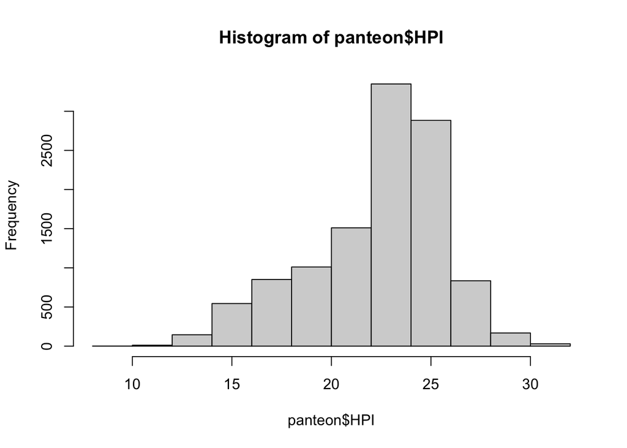

```r
hist(panteon$HPI)
```

### Wykres pudełkowy

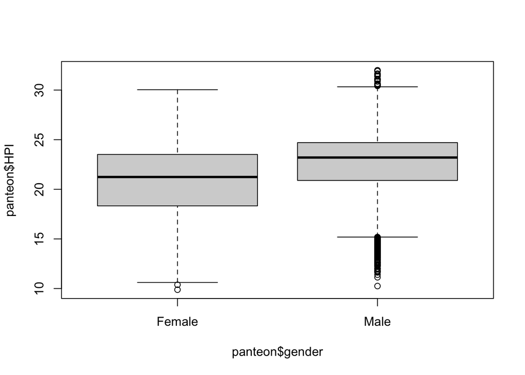

```r
boxplot(panteon$HPI ~ panteon$gender)
```

### Wykres pudełkowy według kategorii

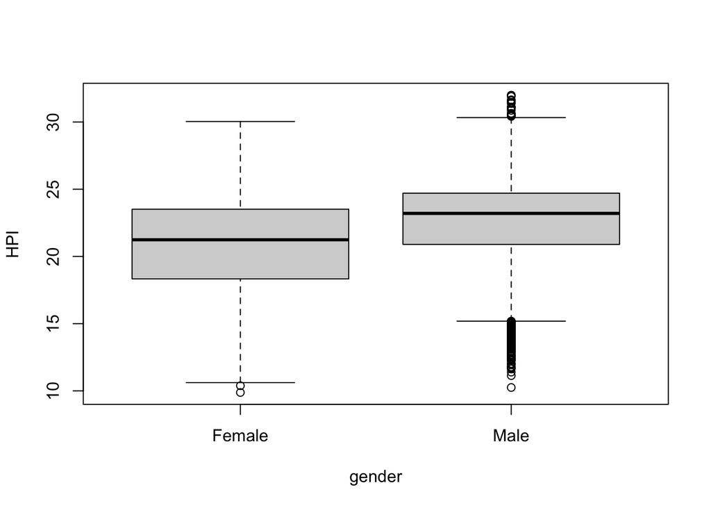

```r
boxplot(HPI~gender, data = panteon)
```

Zadanie: boxplot HPI według kontynentów

Wykres słupkowy.

1. zliczenie funkcją table

```r
(domeny <- table(panteon$domain))
```

```
##
##                 ARTS       BUSINESS & LAW          EXPLORATION
##                 2866                  108                  102
##           HUMANITIES         INSTITUTIONS        PUBLIC FIGURE
##                 1329                 3456                  358
## SCIENCE & TECHNOLOGY               SPORTS
##                 1366                 1756
```

2. wykres słupkowy

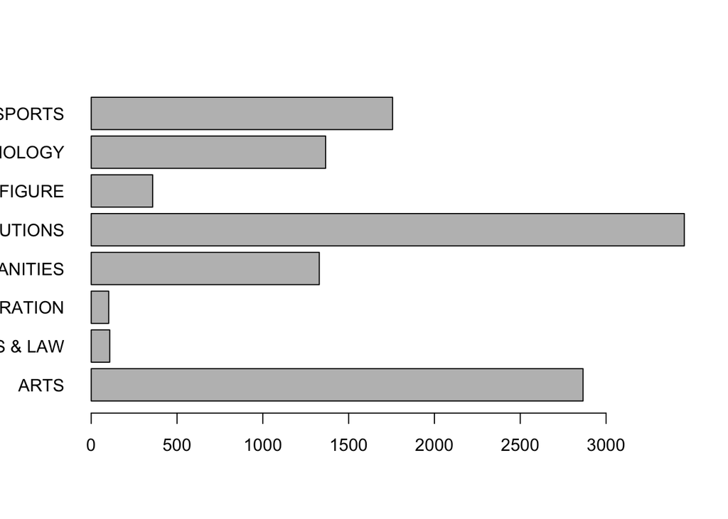

```r
barplot(domeny,
        horiz = TRUE,
        las =1)
```

elemnty dodatkowe

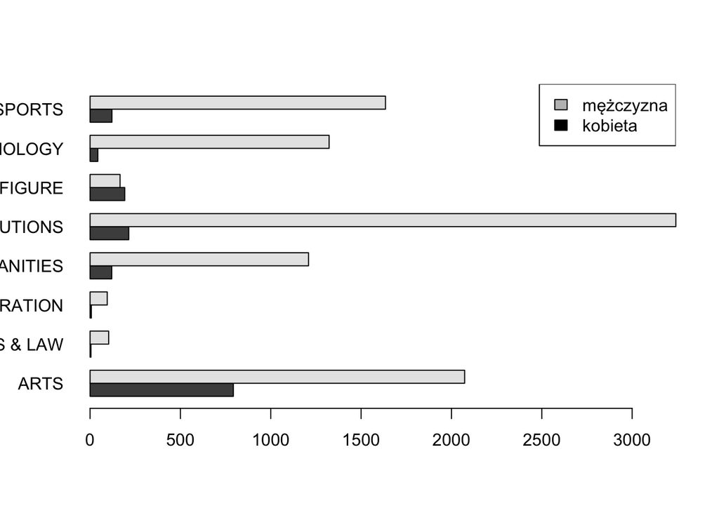

```r
domeny_gender <- table(panteon$gender,
                       panteon$domain)

barplot(domeny_gender,
        las = 1, # orientacja etykiet osi
        beside = TRUE, #słupki obok siebie
        horiz = TRUE)

legend("topright",
       c("mężczyzna", "kobieta"),
       fill = c("grey", "black"))
```

#### Korekta marginesów wykresu w bazowym R

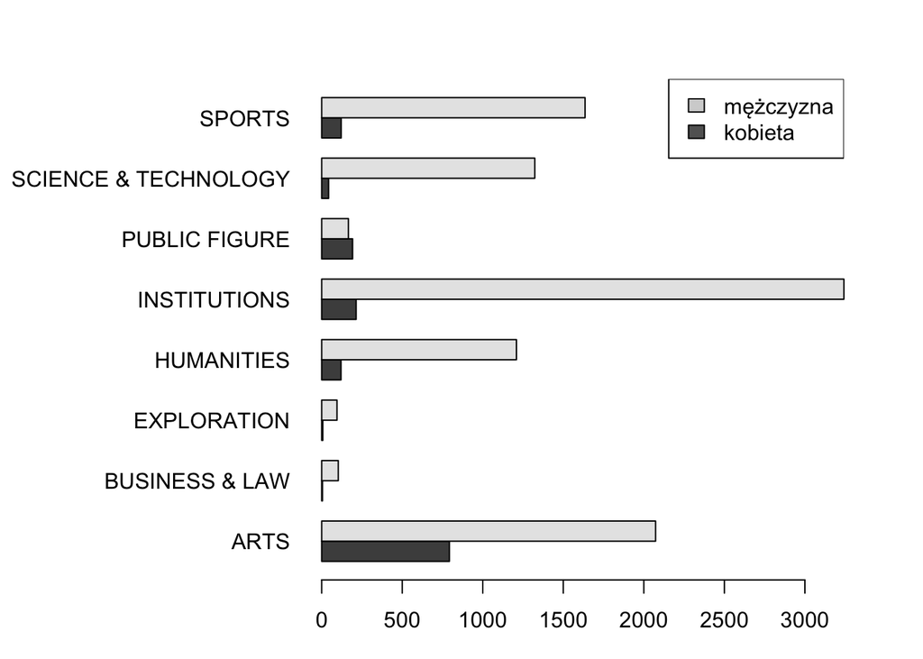

```r
par(mar=c(3,12,3,3)) # marginesy w kolejności par(mar = c(bottom, left, top, right))
#czyli dół, lewy, góra, prawy

barplot(domeny_gender,
        las = 1,
        beside = TRUE,
        horiz = TRUE)

legend("topright",
       c("mężczyzna", "kobieta"),
       fill = c("lightgrey", "gray39"))
```

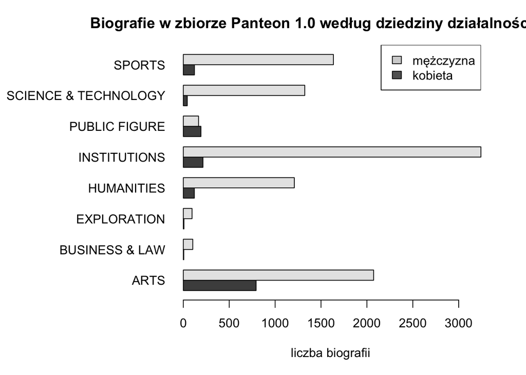

```r
par(mar=c(5,12,3,3)) # marginesy w kolejności par(mar = c(bottom, left, top, right))
#czyli dół, lewy, góra, prawy

barplot(domeny_gender,
        las = 1,
        beside = TRUE,
        horiz = TRUE,
        xlab = "liczba biografii",
        main = "Biografie w zbiorze Panteon 1.0 według dziedziny działalności i płci")

legend("topright",
       c("mężczyzna", "kobieta"),
       fill = c("lightgrey", "gray39"))
```

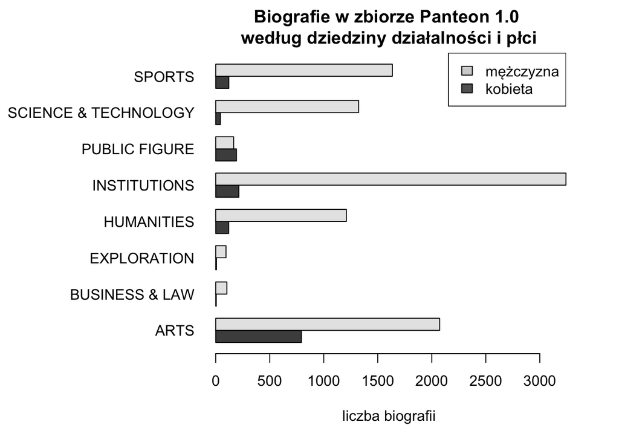

```r
par(mar=c(5,12,3,3)) # marginesy w kolejności par(mar = c(bottom, left, top, right))
#czyli dół, lewy, góra, prawy

barplot(domeny_gender,
        las = 1,
        beside = TRUE,
        horiz = TRUE,
        xlab = "liczba biografii",
        main = "Biografie w zbiorze Panteon 1.0 \nwedług dziedziny działalności i płci")

legend("topright",
       c("mężczyzna", "kobieta"),
       fill = c("lightgrey", "gray39"))
```

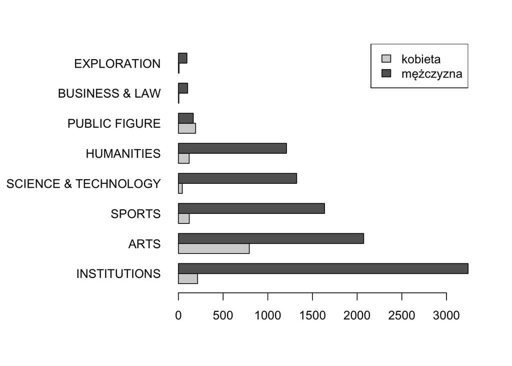

```r
par(mar=c(5,12,3,3))

#  Sortowanie według sum w kolumnach
sorted_indices <- order(colSums(domeny_gender), decreasing = TRUE)

# Zastosowanie sortowania do kolumn
domeny_gender_sorted <- domeny_gender[, sorted_indices]

# Tworzenie wykresu z posortowanymi danymi
barplot(
  domeny_gender_sorted,
  las = 1,
  beside = TRUE,
  horiz = TRUE,
  col = c("lightgrey", "gray39")
)

# Dodanie legendy
legend(
  "topright",
  c("kobieta", "mężczyzna"),
  fill = c("lightgrey", "gray39")
)
```

### Wykres mozaikowy

```r
?mosaicplot
```

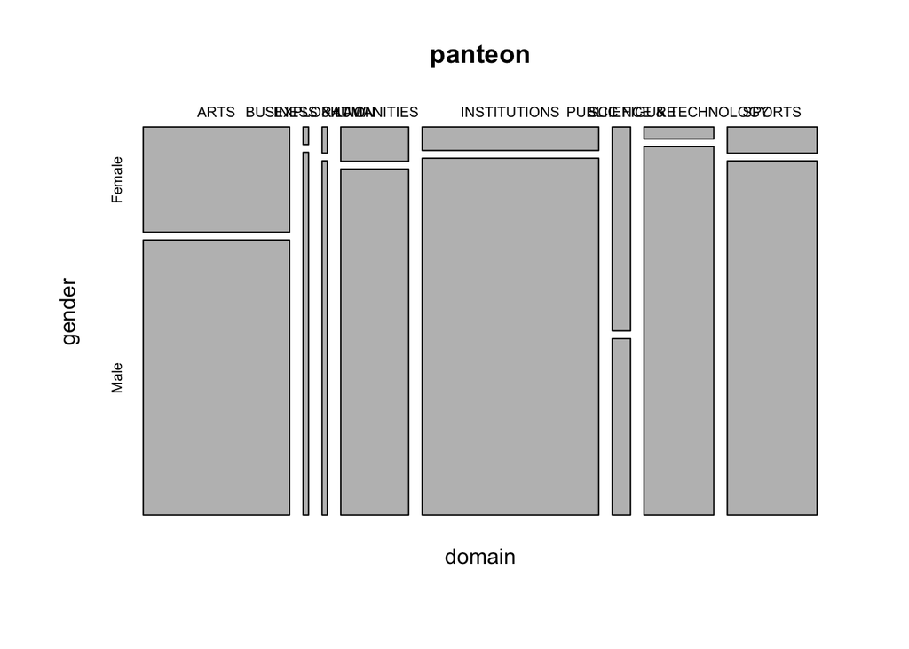

```r
mosaicplot(~domain+gender, data = panteon)
```

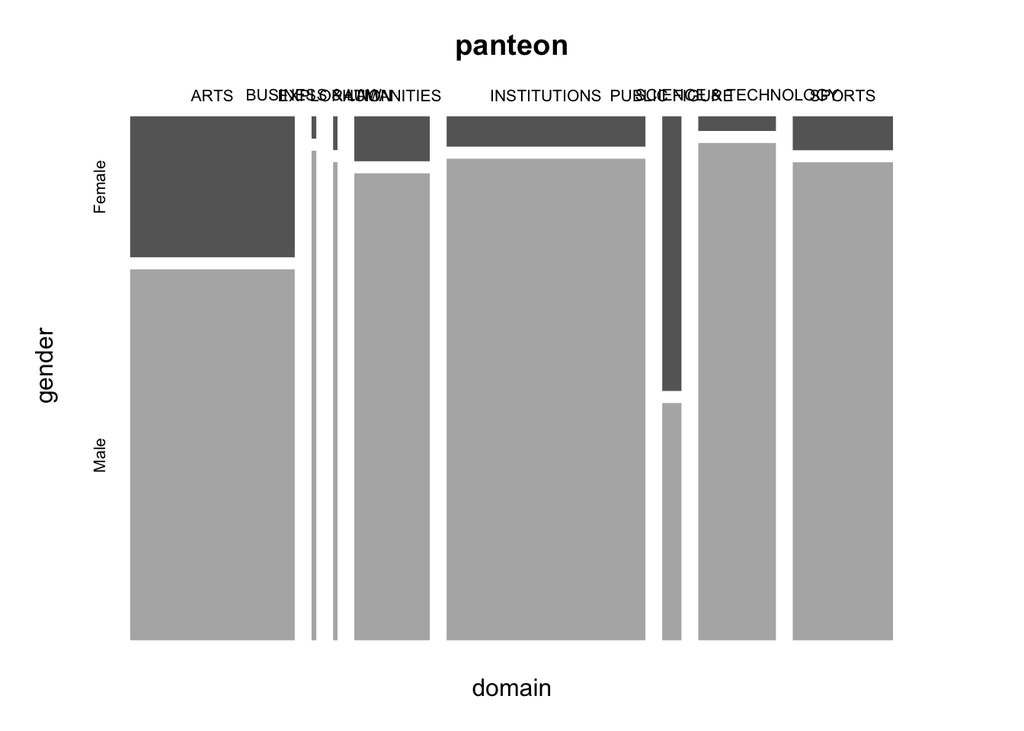

```r
par(mar=c(3,3,3,3))

mosaicplot(~domain+gender,
           data = panteon,
           border = "white",
           col = c("grey40", "grey70"))
```

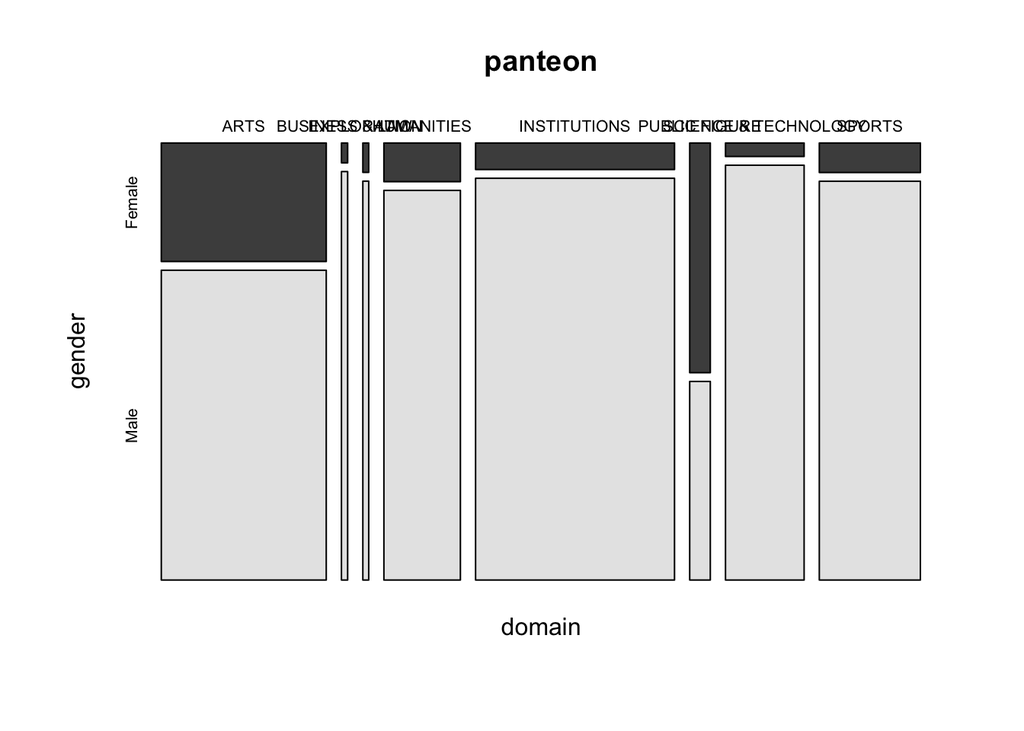

```r
mosaicplot(~domain + gender,
           data = panteon,
           color = TRUE)
```

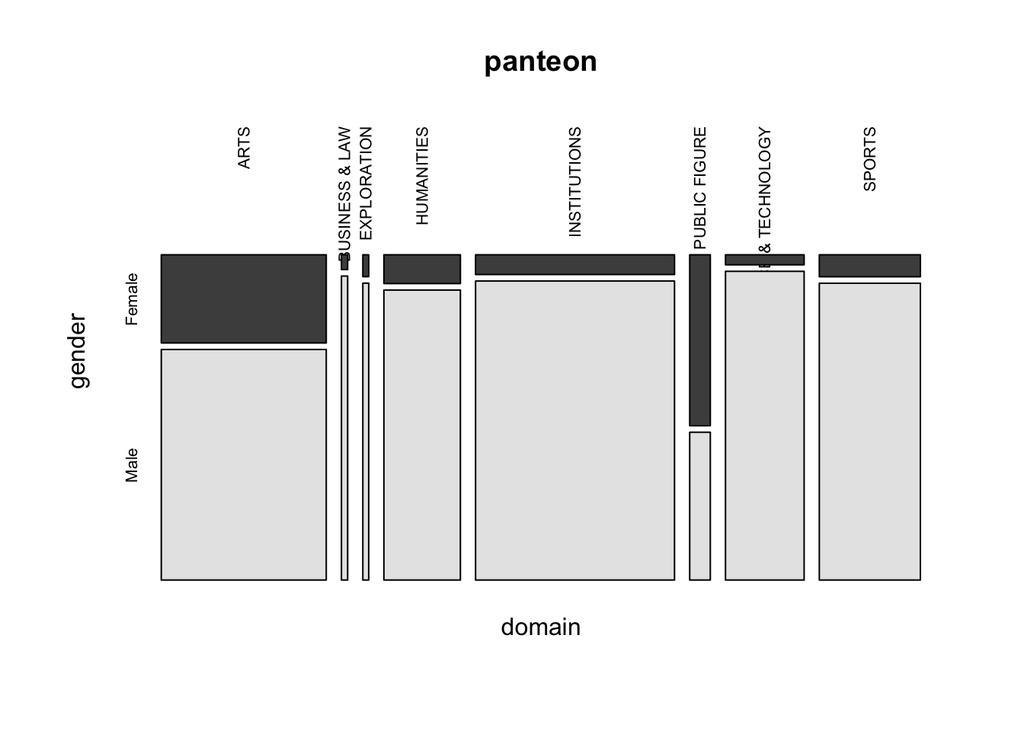

```r
mosaicplot(~domain + gender,
           data = panteon,
           color = TRUE,
           las = 3) #zmienia orientację etykiet
```

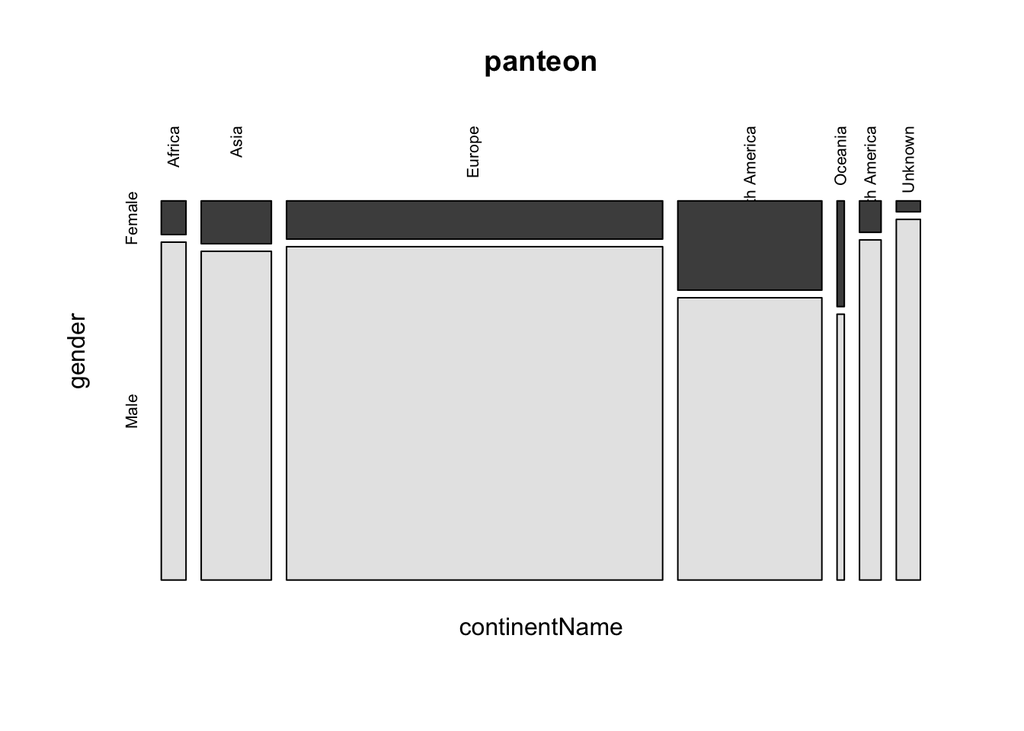

```r
mosaicplot(~continentName + gender,
           data = panteon,
           color = TRUE,
           las = 3)
```

### Wykres gęstości

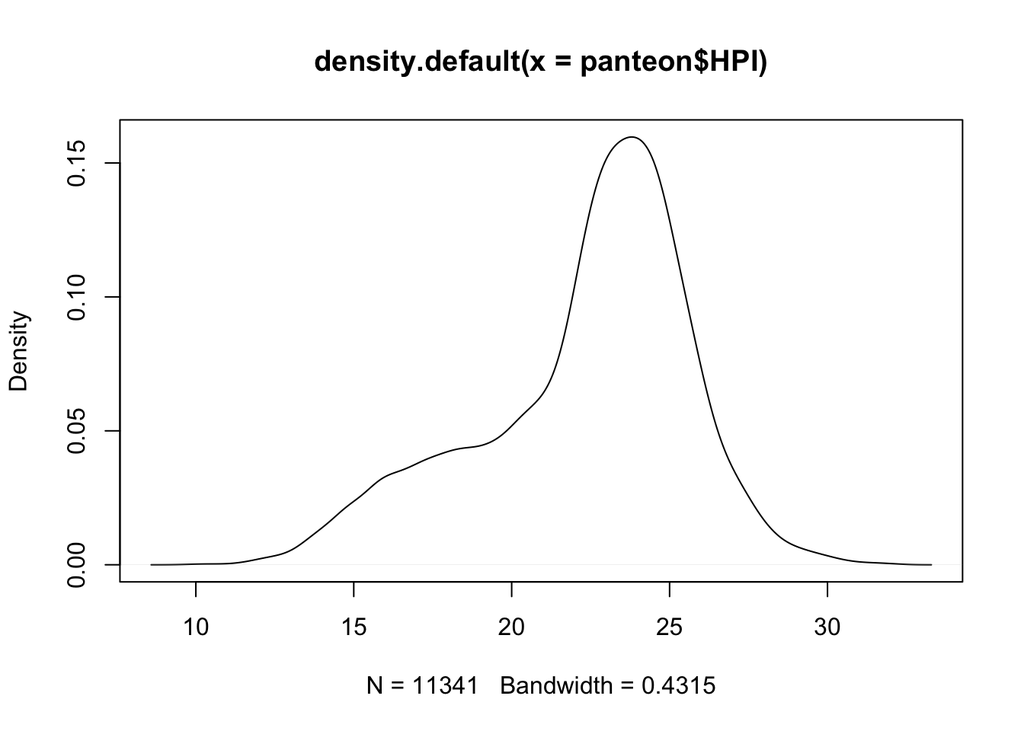

```r
plot(density(panteon$HPI))
```

### ecdf - dystrybuanta empiryczna

Jaki procent obserwacji przyjmuje wartość mniejszą niż x

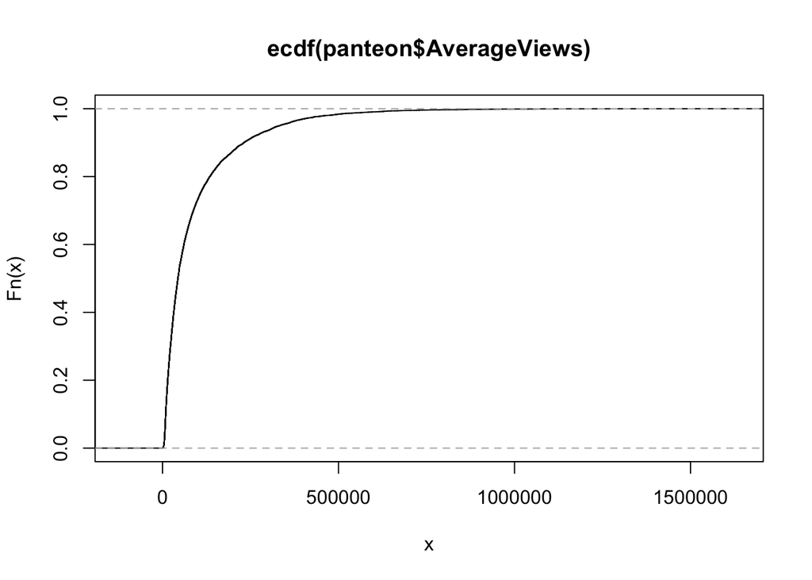

```r
plot(ecdf(panteon$AverageViews))
```

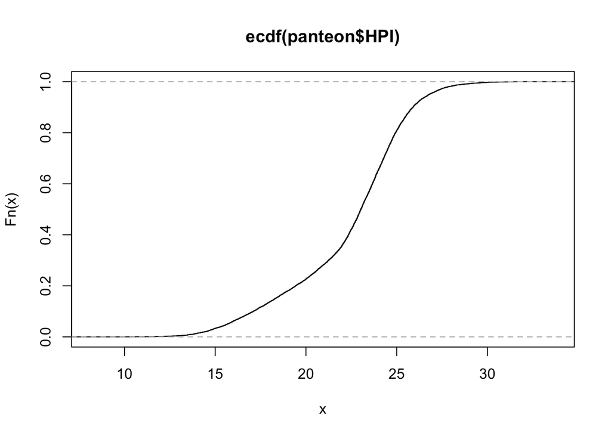

```r
plot(ecdf(panteon$HPI))
```

### Zapisywanie pliku z wykresem w bazowym R

```r
# Otwiera urządzenie do zapisywania w tym wypadku cairo_pdf
cairo_pdf("ecdf.pdf")

plot(ecdf(panteon$HPI))

# Zamyka urządzenie graficzne
dev.off()
```

# Skrypty

## Skróty przydatne w skryptach:

ctrl enter - uruchamia zaznaczony fragment kodu ctrl shift enter - uruchamia cały skrypt

## Indeksowanie

```r
pięć_kolumn <- panteon[,1:5]
```

```r
sześć_wierszy <- panteon[1:6,]
```

```r
sześć_wierszy_pięciu_kolumn <- panteon[1:6, 1:5]

sześć_wierszy_pięciu_kolumn
```

```
## # A tibble: 6 × 5
##   name             countryName    countryCode3   LAT     LON
##   <chr>            <chr>          <chr>        <dbl>   <dbl>
## 1 Abraham Lincoln  UNITED STATES  USA           37.6  -85.7
## 2 Aristotle        Greece         GRC           40.3   23.5
## 3 Ayn Rand         Russia         RUS           60.0   30.3
## 4 Andre Agassi     UNITED STATES  USA           36.1 -115.
## 5 Aldous Huxley    UNITED KINGDOM GBR           51.2   -0.61
## 6 Andrei Tarkovsky Russia         RUS           NA     NA
```

Indeksowanie wektora

```r
panteon$countryName[1:6]
```

```
## [1] "UNITED STATES"  "Greece"         "Russia"         "UNITED STATES"
## [5] "UNITED KINGDOM" "Russia"
```

```r
piąta_kolumna <- panteon[,5]
```

Czwarty element z piątej kolumny

```r
piąta_kolumna[4,]
```

```
## # A tibble: 1 × 1
##     LON
##   <dbl>
## 1 -115.
```

## Praca domowa do modułu 1:

- tworzymy nowy projekt
- umieszczamy w nim plik z danymi
- tworzymy w nim plik r markdown który wczytuje potrzebne biblioteki, wczytuje dane i rysuje na ich podstawie (dowolny) wykres
- kompresujemy folder projektu
- wysyłamy na t.olczyk@uw.edu.pl
- notujemy wszelkie problemy, pytania i trudności jakie pojawią się w tym procesie

## Gdzie szukać dodatkowych informacji:

Plan minimum:

[Ściągawka Rstudio](https://rstudio.github.io/cheatsheets/rstudio-ide.pdf)

Plan dla ambitnych

Rozdział 1-3 Long, J. D. (2020). Język R: Receptury: analiza danych, statystyka i przetwarzanie grafiki, (K. Sawka, Tłum.). Helion SA.

[online po angielsku](https://rc2e.com/gettingstarted)